# データサイエンス特論 2026年度 第3回

本日の内容

- 準備  
  演習問題1
- データの可視化
  - 箱ひげ図  
    演習問題2
  - ヒストグラム  
    演習問題3
  - 散布図  
    演習問題4  
    演習問題5

### 本日の授業用に新たな notebook を用意し，そこに作業内容，演習問題に対する回答を記述，出力し，授業の最後にすべての作業を保存した notebook（*.ipynb）を CoursePower から提出すること．ファイル名は，`名前_20260421.ipynb`という形式にする（例：ohara_20260421.ipynb）．

### また，演習問題に対する解答に関しては，それぞれ「演習問題〇の解答」などの見出しを Markdown にて記述すること．見出しのレベルは `####` を利用すること．

## 準備

### 演習問題1

事前課題の資料を参考に，scikit learn の Iris データセットをデータフレームに読み込み，基本統計量を確認してみよ．  
読み込む変数名は`iris_df`とする．

このファイルの先頭に戻る

## データの可視化

ここでは，Pandas のメソッドを主に利用してデータを可視化（グラフで表現）して確認する．

ここでは，以下のグラフを描画する．

- 箱ひげ図
- ヒストグラム
- 散布図

### pyplot の読み込み

Pandas のグラフ描画機能は，**Matplotlib** というライブラリの`pyplot`を利用する．  
そのため，事前に以下のようにして`pyplot`を読み込んでおく．  
一般的に`pyplot`は`plt`という略称で用いるので，以下ではそれに従っている．

なお，Matplotlib の詳細は，https://matplotlib.org/ にある各ドキュメントを参照すること．  
ユーザガイド：https://matplotlib.org/stable/users/index  
APIリファレンス：https://matplotlib.org/stable/api/index.html  
pyplot の APIリファレンス：https://matplotlib.org/3.5.3/api/_as_gen/matplotlib.pyplot.html

```python
from matplotlib import pyplot as plt
```

可視化のトップに戻る  
このファイルの先頭に戻る

### 箱ひげ図

箱ひげ図は，いわゆる**五数要予約**，つまり，最小値，25%点，中央値，75%点，最大値を描画するものである．  
まずは Iris データの4つの説明変数についての箱ひげ図を描画してみる．  
箱ひげ図の描画には`boxplot()`を利用する．  
以下のようにして箱ひげ図を表示してみよ．

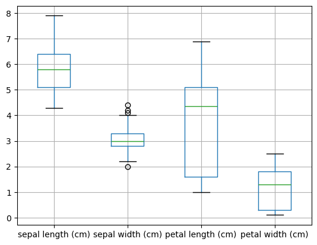

```python
iris_df.boxplot()  # 箱ひげ図の作成
plt.show()         # 箱ひげ図の表示
```

`plt.show()`は，`boxplot()`で描画されたグラフオブジェクトを実際に表示する役割をもつ．

描画された図の長方形の上辺が75%点を，下辺が25%点を表す．そのため，この長方形の高さが，いわゆる**四分位範囲（IQR: Inter Quantile Range）** に相当し，この中にその変量のデータの半分が存在していることを意味する．  
一方，長方形の中に引かれた水平線は中央値を表す．  
長方形から上下に延びた**髭**は，通常，上側が最大値，下側が最小値を表す．ただし，一般には髭は四分位範囲の1.5倍までとし，それを超えるデータ値は個別に表示することになる．いわゆる**外れ値**扱いとなる．  
上記の例では，`sepal width (cm)`の上下に外れ値があることがわかる．

上記の例では横軸のラベルが近接しており，やや見づらいため，グラフの描画領域を変更してみる．  
具体的には，`plt.figure()`を使って以下のように調整することができる．

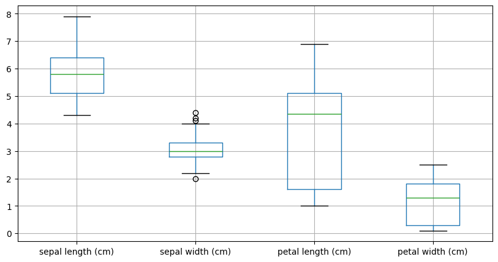

```python
plt.figure(figsize=(10,5))  # 描画領域の指定（インチ）
iris_df.boxplot()           # 箱ひげ図の作成
plt.show()                  # 箱ひげ図の表示
```

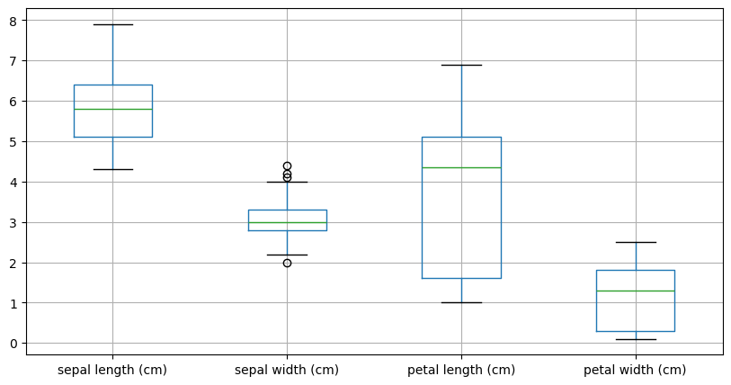

```python
#plt.figure(figsize=(10,5))  # 描画領域の指定（インチ）
iris_df.boxplot(figsize=(10,5))           # 箱ひげ図の作成
plt.show()                  # 箱ひげ図の表示
```

一部の説明変数についてのみ箱ひげ図を描画したい場合は，列を指定したうえで`boxplot()`を利用する．  
たとえば，iris_df の最初の2つの変数だけを利用する場合は以下のようにする．

```python
iris_df.iloc[:,:2].boxplot()      # 箱ひげ図の作成
plt.show()                        # 箱ひげ図の表示
```

[output not shown]

#### 図のファイルへの保存

表示したグラフは，png 形式等の図として保存することができる．  
具体的には，`plt.savefig()`を利用し，括弧の中に保存するファイルの名前を記述する．  
たとえば，上記の箱ひげ図を作業フォルダの中に`iris_boxplot1.png`という名前で保存したい場合は以下のようにする．

```python
iris_df.iloc[:,:2].boxplot()      # 箱ひげ図の作成
plt.savefig('iris_boxplot1.png')  # 箱ひげ図のファイルへの保存
plt.show()                        # notebook 上での箱ひげ図の表示
```

[output not shown]

作業フォルダに`iris_boxplot1.png`とうファイルが生成されていること，および，その内容を確認すること．  
なお，`plt.savefig()`を実行時に`plt.show()`を実行しなかった場合，次に箱ひげ図以外の図を描画して`plt.show()`を実行した際に，ファイルに保存した図（描画されたが表示されなかった箱ひげ図オブジェクト）が表示されるので注意すること．

図は通常 72dpi という解像度で出力される．ファイルサイズは小さいが，少し粗く，引き伸ばすとぼやけた画像になりやすい．  
引き伸ばしても鮮明な画像にしたい場合は，ファイル出力時の解像度を高くする．  
具体的には，`savefig()`のカッコ内で`dpi=`で解像度を指定する．  
たとえば，上記の箱ひげ図を2倍の解像度，つまり144dpiで保存したければ，以下のようにする．

```python
iris_df.iloc[:,:2].boxplot()                   # 箱ひげ図の作成
plt.savefig('iris_boxplot1_144.png', dpi=144)  # 144dpiでの箱ひげ図のファイルへの保存
plt.show()                                     # notebook 上での箱ひげ図の表示
```

[output not shown]

保存されたファイルを開くと，72dpiと144dpiでは図の大きさが異なることがわかる．

### 演習問題2

#### 演習問題2-1

事前課題の資料を参考に，scikit learn の乳がんデータセットをデータフレームに読み込み，基本統計量を確認せよ．  
ただし，省略されている列についても確認すること．Pandas の `set_option()` にて `display.max_columns` の設定値を変更すれよばよい．  
なお，データフレームとして読み込む変数名は`breast_df`とする．

#### 演習問題2-2

演習問題2-1の結果から，乳がんデータセットにおいてスケールの大きく異なる列を2つ特定し，その2つの列に対する箱ひげ図，残りの列に対する箱ひげ図をそれぞれ描画せよ．  
特定の2列以外の列の箱ひげ図を表示する場合，リスト内包表記を用いて当該2列のインデックスを除外すればよい．  
なお，特定の2列以外の列に対する箱ひげ図は，属性名が重ならないように描画領域の大きさを調整すること．その場合，モニタ上では文字の視認性が落ちるため，ファイルに保存して拡大表示して内容を確認すること．

可視化のトップに戻る  
このファイルの先頭に戻る

### ヒストグラム

次に，データ値の出現頻度を視覚化するヒストグラムだけを描画してみる．  
具体的には，Pandas の `hist()` メソッドを利用する．  
たとえば，iris_df のヒストグラムを描画するには以下のようにする．

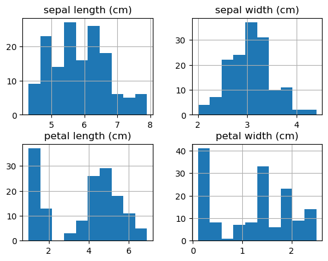

```python
iris_df.hist()    # ヒストグラムの作成
plt.show()        # ヒストグラムの表示
```

上記のように，各変数についてのヒストグラムが描画される．  
ヒストグラムにおける各棒は**ビン**と呼ばれ，ビンの数はデフォルトでは10となっている．  
つまり，このヒストグラムは，値の範囲全体を10分割し，それぞれの範囲に存在しているデータ数（**頻度**もしくは**度数**）を棒グラフとして描画したものとなっている．  
この分割数を変えたい場合は`bins=`で指定する．  
たとえば，`iris_df`のヒストグラムのビン数を20にして描画するには，以下のようにする．

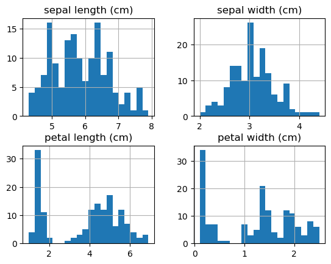

```python
iris_df.hist(bins=20)    # ビン数を20にしたヒストグラムの作成
plt.show()               # ヒストグラムの表示
```

#### データフレームへの列の追加

Irisデータは，実際には3種類のアヤメの情報が50個ずつ収録されたものとなっており，そのような場合，アヤメの種類（**クラス**）ごとに上記のデータの分布がわかると，よりデータの理解が深まる．  
そのために，まずは現在のデータフレームに各事例が所属するアヤメの種類（クラス）を表す列を追加する．  
具体的には，`iris`のプロパティのうち`target`の情報を新しい列として追加する．  
ここでは，新しい列の名前を`species`とすると，以下のようにすれば新しい列を追加することができる．

```python
iris_df['species'] = [iris.target_names[i] for i in iris.target]
```

上記の`for i in iris.target`の部分では，`target`の内容を1つずつ読み出して変数`i`に保存している．  
この`target`の内容は，0，1，2のいずれかであり，それぞれ`target_names`に書かれているクラス名に対応している．  
具体的には，0 は`setosa`，1 は`versicolor`，2 は`virginica`となる．  
`iris.target_names[i]`はその対応関係に基づいて，これらの数字を具体的なクラスの名前に置き換えている．  
その結果として得られた150個の事例に対する**クラス名のリスト**が上記の等号の右辺で作成され，それを追加する列の内容としている．

実際にデータフレームの先頭を`head()`で確認してみる．

```python
iris_df.head()
```

|  | sepal length (cm) | sepal width (cm) | petal length (cm) | petal width (cm) | species |
| --- | --- | --- | --- | --- | --- |
| 0 | 5.1 | 3.5 | 1.4 | 0.2 | setosa |
| 1 | 4.9 | 3.0 | 1.4 | 0.2 | setosa |
| 2 | 4.7 | 3.2 | 1.3 | 0.2 | setosa |
| 3 | 4.6 | 3.1 | 1.5 | 0.2 | setosa |
| 4 | 5.0 | 3.6 | 1.4 | 0.2 | setosa |

最後に`species`という列が増えていることがわかる．

実際に，以下のようにすると，それぞれの変数についてクラスごとに頻度を集計することができる．

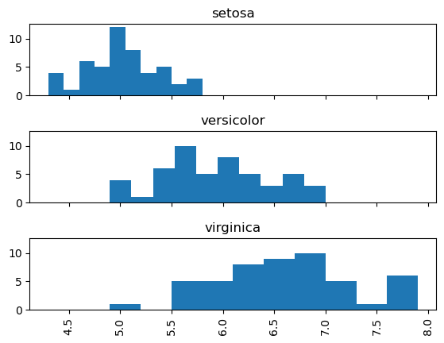

```python
# column で集計する変数を指定
# by でクラス情報が記述されている列を指定
# sharex はすべてのグラフで x軸の範囲を揃えたいときに True にする
# sharey はすべてのグラフで y軸の範囲を揃えたいときに True にする
# layout は個々のグラフの配置を指定する．(3,1)は3行1列の意味
iris_df.hist(column='sepal length (cm)', by='species', sharex=True, sharey=True, layout=(3,1))
plt.show()               # ヒストグラムの表示
```

上記のコメントに書いたように，`column=`で対象となる変数を指定し，`by=`でクラス情報が含まれる列を指定する．  
また，複数のグラフを並べて比較する場合は，x軸の範囲とy軸の範囲は同じであるほうが比較しやすく，誤解も生じないため，`sharex=True`および`sharey=True`で軸を揃えておくとよい．  
`layout`は個々の図の配置を決めるものであり，軸を統一したら横一列もしくは縦一列のいずれかに並べると比較しやすくなる．

### 演習問題3

#### 演習問題3-1

乳がんデータセットに対するヒストグラムを描画してみよ．  
すべての属性を対象とし，文字列が重ならないように描画領域の大きさを調整すること．

#### 演習問題3-2

乳がんデータセットを読み込んだ `breast_df` に，乳がんデータセットの目的変数の値に応じたクラス名の列を追加し，いずれかの属性に対してクラスごとに集計したヒストグラムを描画せよ．追加する列の名前は `class` とする．

可視化のトップに戻る  
このファイルの先頭に戻る

### 散布図

次に，2つの変量の関係を把握することができる散布図を描画してみる．  
散布図も Pandas の`plot.scatter()`を使って簡単に描画することができる．  
ただし，`scatter()`を用いる場合，x軸とy軸，それぞれにどの変数を割り当てるかを明示的に指定しなければならない．  
たとえば，Irisデータの`sepal length (cm)`をx軸．`sepal width (cm)`をy軸とした散布図を描画する場合，以下のようにする．

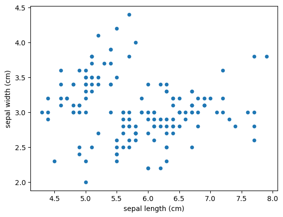

```python
iris_df.plot.scatter(x='sepal length (cm)', y='sepal width (cm)')   # 散布図の作成
plt.show()      # 散布図の表示
```

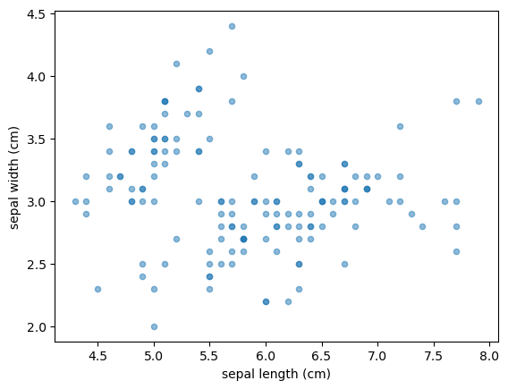

```python
iris_df.plot.scatter(x='sepal length (cm)', y='sepal width (cm)', alpha=0.5)  # 点の透過度を半減させた散布図の作成
plt.show()       # 散布図の表示
```

上の散布図を見ると，x 軸と y 軸のメモリ間隔が同一ではないことに気づく．このような場合，2つの変量間の関係を誤解する可能性があるため，x 軸と y 軸の比率（アスペクト比）は統一しておくべきである．  
そのためには，`plt.gca()` を利用して，描画領域に対する軸オブジェクトを事前に取得し，そのオブジェクトに対して `set_aspect()` を以下のように使って等比率を指定する．

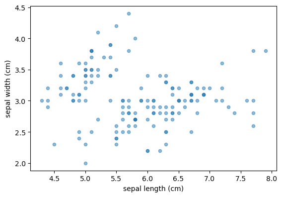

```python
ax = plt.gca()           # 軸オブジェクトの取得
ax.set_aspect('equal')   # アスペクト比の指定
iris_df.plot.scatter(x='sepal length (cm)',
                     y='sepal width (cm)',
                     alpha=0.5,
                     ax=ax)  # 点の透過度を半減させた散布図の作成
plt.show()       # 散布図の表示
```

#### 散布図行列

説明変数が2つの場合は，両者の関係を1つの散布図で描画すれば十分であるが，説明変数が3つ以上ある場合，すべての説明変数の組合せ，もしくは特定の複数の説明変数の組合せに対して散布図を描画する場合がある．その際，個々の散布図を個別に描画していては説明変数の数が多い場合は非効率的であるため，**散布図行列**としてすべての変数の組合せに対する散布図を行列として表示する関数を用いる．  
一般には，**seaborn** という描画ライブラリを利用する．このライブラリは通常`sns`という略称で利用される．まず，以下のようにして seaborn を読み込んでおく．

なお，seaborn の詳細は以下のドキュメントを参照のこと．  
APIリファレンス：https://seaborn.pydata.org/api.html

```python
import seaborn as sns
```

散布図行列の描画には seaborn の`pairplot()`という関数を利用する．  
たとえば，Irisデータの4つの説明変数すべての組合せに対する散布図行列は以下のようにして描画する（少し時間がかかる）．

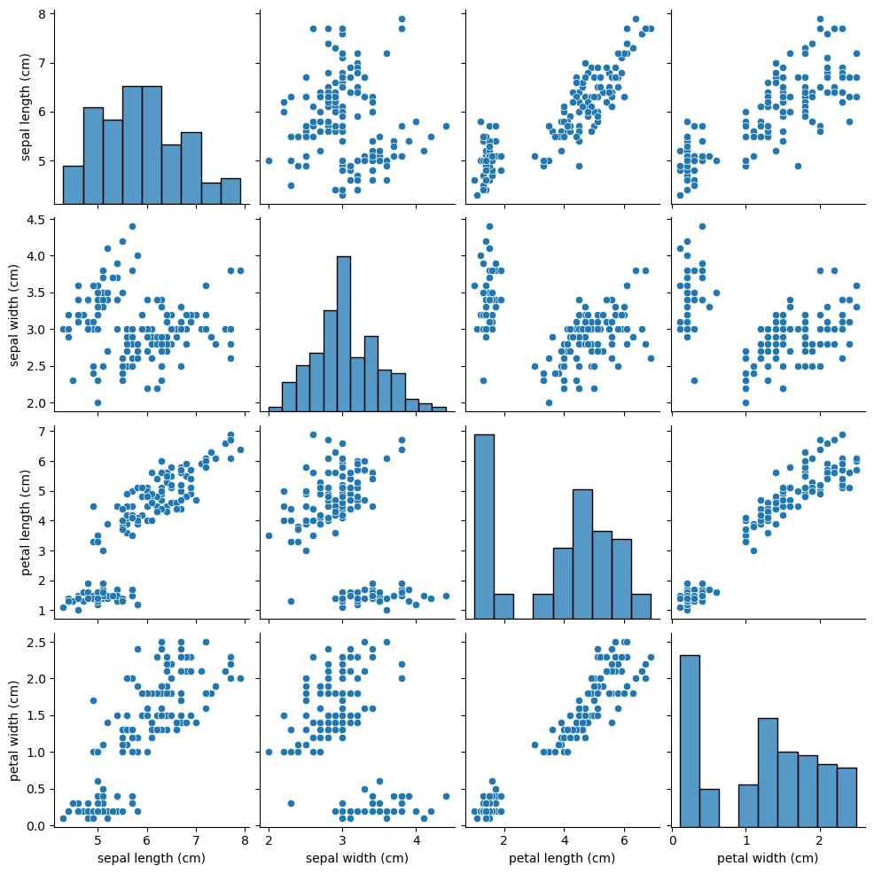

```python
sns.pairplot(iris_df)    # 散布図行列の作成
plt.show()               # 散布図行列の表示
```

散布図行列の対角成分は同じ変数の組合せになるため，散布図ではなくその変数に対するデータ値の**ヒストグラム（度数分布）**が描画される．  
このように散布図を描画すると，どの変数とどの変数の間に**相関関係**があるのかを俯瞰することができる．

#### クラス情報を反映した散布図行列

散布図上の各点は，1つのデータ（サンプル）表している．しかし，同じ色で描画された場合，どの点がどのクラスに属するサンプルを表しているのかは把握できない．  
実際には，クラスごとに異なる色で表現すると，クラスごとの関係性も俯瞰することができる．  
そのような描画をするためには，先ほどの指定に加えて，`hue=`を使って各事例のクラスの情報が含まれている列を指定する．こうすることで，自動でクラスごとに色分けをしてくれる．  
具体的には，iris_df については以下のようにする．

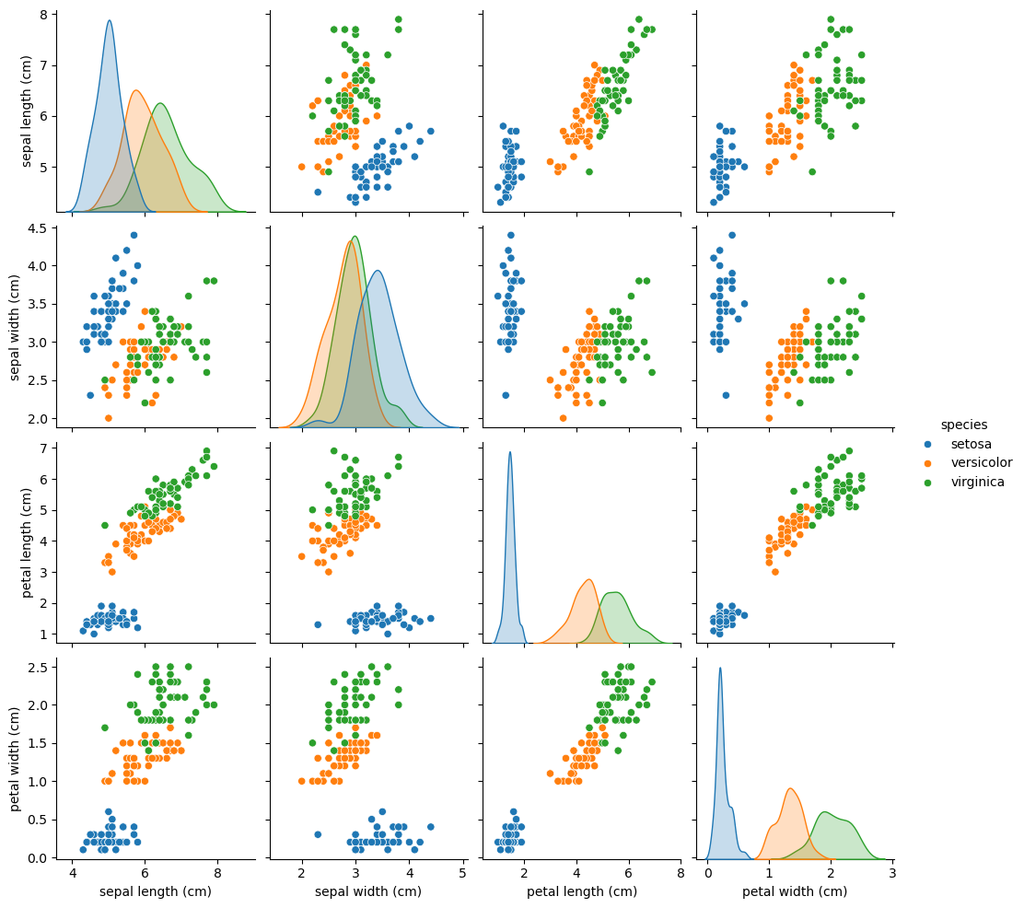

```python
sns.pairplot(iris_df, hue='species')    # クラス情報を考慮した散布図行列の作成
plt.show()                              # 散布図行列の表示
```

上記のように色分けされると，各変数の値とクラスの関係がよりわかりやすくなる．  
なお，クラス情報を指定すると，対角成分が棒グラフ（**ヒストグラム**）から滑らかな連続グラフに変化する．このグラフは**カーネル密度推定**と言われるものであり，クラスごとのヒストグラムの頂点を連続的な関数で近似したものとなっている．

### 演習問題4

乳がんデータセットに対してもクラスを考慮した散布図行列を描画してみよ．  
ただし，属性すべてを対象とすると時間がかかるので注意すること．  
可能な者は，いくつかの属性を選択し，それらに対しての散布図行列を描画せよ．

#### 相関行列の確認

散布図行列は，属性数が多くなると描画に時間がかかり，視認性も落ちる．そのため，属性数が多い場合，すべての属性の組み合わせに対する相関係数を行列で表記する相関行列を見るほうがデータを俯瞰するには都合がよい場合がある．  
Pandas では `corr()` で相関行列を表示することができる．  
たとえば，Iris データセットに対しては，以下のようにして相関行列を確認できる．

```python
iris_df.iloc[:,0:4].corr()
```

|  | sepal length (cm) | sepal width (cm) | petal length (cm) | petal width (cm) |
| --- | --- | --- | --- | --- |
| sepal length (cm) | 1.000000 | -0.117570 | 0.871754 | 0.817941 |
| sepal width (cm) | -0.117570 | 1.000000 | -0.428440 | -0.366126 |
| petal length (cm) | 0.871754 | -0.428440 | 1.000000 | 0.962865 |
| petal width (cm) | 0.817941 | -0.366126 | 0.962865 | 1.000000 |

### 演習問題5

乳がんデータセットに対する相関行列を確認してみよ．

可視化のトップに戻る  
このファイルの先頭に戻る